# Project: Ad Hoc Network Simulation

Wireless networks are all around us. Traditionally, cell phones communicate with a base-station to send and receive calls. Now, a new idea of organizing networks is to avoid the need for a central base-station that coordinates communications. Instead, messages are relayed by “hopping” from one node to the next to the next until it reaches its destination. These are called ad hoc networks. A very basic aspect of ad hoc networks is how the communication and complete connectivity changes with respect to the broadcasting power.

Therefore, this project will focus on this aspect. In specific, we would first use acceptance-rejection sampling to generate 1000 2-dimensional ad hoc networks consisting of n nodes based on a given density function, and find the smallest broadcasting power for each network such that it is completely connected. Building further on that, we can look into the distribution of the value of broadcasting power. Last, we would change n, which is the number of nodes, and replicate the above process to find out how the number of nodes influences the required broadcasting power.

First, we source the density function nodeDensity() into R. It takes two inputs: x and y, two numeric vectors of the same length. The function returns a numeric vector of values that are proportional to node density at the (x, y) pairs.

```r
source("http://www.stat.berkeley.edu/users/nolan/data/nodeDensity.R")
```

## Generating nodes in an ad hoc network

The next step is to generate nodes in an ad hoc network based on the density function. For this purpose, we apply the acceptance-rejection sampling. We want the smallest rectangular region that encompasses the density function, thus we need to find the maximal value of the density function on its domain, which is the [0, 100] * [0, 100] plane. So we generate a grid on this plane, and search over it for the maximum of the density.

```r
# Here we take by = 0.5, which is small, to make sure that the grid is dense enough so that the error of the max of the density is small
x = seq(from = 0, to = 100, by = 0.5)
y = seq(from = 0, to = 100, by = 0.5)
# Creating a grid from vectors x and y
gridPts = expand.grid(x, y)
# Searching over the grid for the maximum of the density
zMax = max(nodeDensity(gridPts[[1]], gridPts[[2]]))
```

After running the previous code chunk, we find that zMax = 3.983498. We take zMAX = 4 when generating ad hoc networks.

```r
genNodes = function(n) {
  # Generating points in a 3-dimensional rectangle
  x1 = runif(100 * n, min = 0, max = 100)
  y1 = runif(100 * n, min = 0, max = 100)
  z1 = runif(100 * n, min = 0, max = 4)
  # Keeping the points  falling in the 3-d region beneath the density
  keep = z1 <= nodeDensity(x1, y1)
  x1 = x1[keep]
  y1 = y1[keep]
  # Using the (x, y) coordinates of these "kept" points as the sample
  random = sample(seq(0, length(x1)), n)
  return(matrix(c(x1[random], y1[random]), ncol = 2))
}
```

## Finding the smallest radius Rc such that the network is completely connected

Note that here the radius R around every node actually denotes the broadcasting power levels.

Since each node must be connected to at least one other node, then Rc must be at least as large as the greatest row-wise minimum (ignoring the diagonal element). Similarly, if Rc is greater than the maximum distance in a row, then the corresponding node will be connected to all of the other nodes, i.e., the network will be connected. So Rc is no greater than the smallest row-wise maximum.

So we write a function, findRange() to find the range of Rc to search over based on the above observations. This function has one input: the distance matrix called mat. It is required. The function returns a numeric vector of length 2, with the minimum and maximum values of R to search over.

```r
# Finding the range of Rc
  findRange = function(mat) {
    return(c(max(apply(mat, 1, function(x) min(x[x!=min(x)]))), min(apply(mat, 1, max))))
  }
```

Furthermore, to find the smallest radius Rc such that the network is completely connected for a given configuration of nodes, we can use the bisection method based on the range of Rc we just derived. However, for each value of Rc, we’ll have to decide whether it works in the sense that it is large enough for the network to be completely connected. To do this, we introduce a new notion - transition matrix. It can be generated according to the distance matrix of our nodes.

Specifically, for a message located at node i, i = 1,…,n, the chance the message moves to node j is 0 if these two nodes are further than R away from each other. Otherwise, it is 1/ki where ki is the number of nodes within R of node i (including node i itself). The n times n matrix of these transition probabilities is called P, aka the transition matrix.

Now, if vm is a n × 1 vector of probabilities that a message is at any one of the n nodes at one “instant”, then Pvm = vm+1 is the distribution of locations of the message at the next instant. And Pvm+1 = vm+2 is the distribution for the next instant.

Mathematical properties of transition matrices tell us many things. Namely, 1. the distribution of the locations of the message settles down, i.e., there is some v where Pv = v. 2. This equation indicates that the steady state (i.e. v) is the eigenvector of the transition matrix associated with the eigenvalue of 1. 3. The eigenvalues of P are all real and less than or equal to one. 4. If the network of nodes is fully connected, then there is one unique steady-state solution. In this case, only the largest eigenvalue is one.

The above properties imply that the size of the second largest eigenvalue of P is key to determining if the network is connected.

To sum up, in a bid to determine whether a particular R works, we need to write a helper function called findTranMat() to find the transition matrix based on a distance matrix and a value for R. That is, this function takes as an input a distance matrix called mat and a value for R, called R. Both of these are required arguments. The function returns the transition matrix P for these inputs.

```r
# Generating the transition matrix
  findTranMat = function(mat, R) {
    n = nrow(mat)
    TranMat = matrix(0, nrow = n, ncol = n)
    for(i in 1:n) {
      connect = mat[i, ] <= R
      connectNum = sum(connect)
      TranMat[i, ][connect] = 1 / connectNum
    }
    return(TranMat)
  }
```

According to the analysis before, the size of the second largest eigenvalue of P is key to determining if the network is connected. So we write anthoer helper function called getEigen2() which returns the second largest eigenvalue of a matrix. The input to this function has one argument, which is required. The parameter is a matrix, called mat.

```r
# Getting the second largest eigenvalue of a matrix
getEigen2 = function(mat) {
  eigen(mat)[[1]][2]
}
```

With the helper functions, namely findRange(), findTranMat() and getEigen2(), we can finally establish the function called findRc(). The first input parameter is nodes, which is required. This input is a 2-column matrix of the x and y locations of the nodes. The second input parameter is tol. It has a default value of 0.05, which is the tolerance level for how close we need to get to the true value of Rc for the provided configuration. The return value is a numeric vector of length 1, that holds the value of Rc (or a value close to it).

```r
findRc = function(nodes, tol = 0.05) {
  distBNodes = as.matrix(dist(nodes))
  range = findRange(distBNodes)
  if(range[1] == range[2]) {
    return(range[1])
  } else {
    n = ceiling(log2((max(range) - min(range)) / tol))
    for(i in 1:n) {
      Rc = sum(range) / 2
      TranMat = findTranMat(distBNodes, Rc)
      if(isTRUE(all.equal(1, Mod(getEigen2(TranMat))))) {
        range[1] = Rc
      } else range[2] = Rc
    }
    return(range[2])
  }
}
```

## Examining the distribution of Rc in 1000 simulations for different numbers of nodes

In a bid to probe into how the number of nodes influences the required broadcasting power, we choose different number of nodes, namely 50, 75, 100, 125, 150 and 175, and look at the distribution of Rc in 1000 simulations in each circumstance.

Notice that to reproduce the simulation results, we use set.seed() to control the seed.

```r
# Finding Rc for different numbers of nodes, each with 1000 simulations and placing them in a data frame with 1000 rows and 6 columns
RC = data.frame(Rc50 = rep(0, 1000), Rc75 = rep(0, 1000), Rc100 = rep(0, 1000), Rc125 = rep(0, 1000), Rc150 = rep(0, 1000), Rc175 = rep(0, 1000))

# Numbers of nodes are chosen as 50, 75, 100, 125, 150 and 175
numNodes = seq(from = 50, by = 25, length = 6)

j = 1
for(n in numNodes) {
  # Setting the seed for each number of nodes
  set.seed(12345678)
  for(i in 1:1000) {
    RC[i, j] = findRc(genNodes(n))
  }
  j = j + 1
}
```

Now, we have a data frame RC with 6 vectors of length 1000. Each vector records the 1000 Rc values derived from 1000 simulations for a particular number of nodes.

Next, we’ll examine the distribution of these Rc values. To start with, we need to massage data into format suitable for analysis.

```r
# Stacking Rc for different numbers of nodes
RC2 = data.frame(Rc = with(RC, c(Rc50, Rc75, Rc100, Rc125, Rc150, Rc175)))

# Creating a new variable "Type" in RC
RC2$type = rep(c("Rc50", "Rc75", "Rc100", "Rc125", "Rc150", "Rc175"), each = 1000)
```

Then we can make graphs to explore the distribution of Rc for different numbers of nodes. Since there is one quantitative variable, we use superposed density curves for comparison.

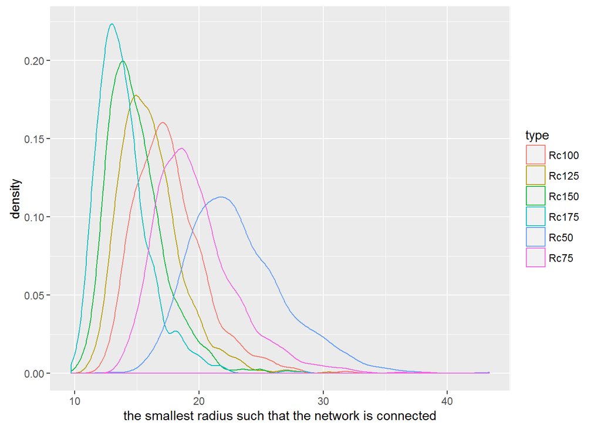

```r
# Plotting the distribution of Rc
require(ggplot2)
ggplot(data = RC2) +
  geom_density(aes(x = Rc, color = type)) +
  scale_x_continuous(name = "the smallest radius such that the network is connected")
```

From the plot, we can see that (i) For each n, the distribution of Rc is right-skewed with a long right tail and a single mode. (ii) As n becomes larger, the density curve is more shifted to the left. In the meanwhile, it also appears that the spread in Rc is smaller and that the distribution of Rc has shorter tails.

Next, we pick one n to study the node configuration in greater detail. This n should not be so large that plots would be hard to view. Thus we choose n = 50. Note that it’s actually more efficient space wise to save the 1000 sets of nodes themselves than the 1000 random seeds that generated the nodes. We’ll go for the first approach.

```r
# Saving the 1000 sets of nodes when n is 50
nodes = vector(length = 1000, mode = "list")
set.seed(12345678)
for(i in 1:1000)  nodes[[i]] = genNodes(50)

# Finding four of 1000 node configurations corresponding roughly to the min, max, median and mean values of Rc50
nodes_min = nodes[[which(RC[, 1] == min(RC[, 1]))]]
nodes_max = nodes[[which(RC[, 1] == max(RC[, 1]))]]
diffmedian = abs(RC[, 1] - median(RC[, 1]))
nodes_median = nodes[[head(which(diffmedian == min(diffmedian)), 1)]]
diffmean = abs(RC[,1] - mean(RC[,1]))
nodes_mean = nodes[[head(which(diffmean == min(diffmean)), 1)]]
```

Now we can then plot the network of connected points for four of 1000 node configurations corresponding roughly to the min, max, median and mean values of Rc50.

```r
# Plotting the network
plotNetwork = function(nodes) {
  Rc = findRc(nodes)
  x = nodes[, 1]
  y = nodes[, 2]

  # Transferring the transition matrix to a logical matrix
  distBNodes = as.matrix(dist(nodes))
  connect = matrix(as.logical(findTranMat(distBNodes, Rc)), nrow = 50, ncol = 50)

  # Making the lower triangle(including diagonal entries) of the matrix connect FALSE, to avoid two-way connecting and self-connecting
  connect[lower.tri(connect)] = FALSE

  # Calculating the number of nodes within Rc of each node(including itself), i.e., the number of nodes that each node can be connceted to
  repeatTimes = apply(connect, 1, sum)

  # Creating a data frame that contains the x-coordinate and y-coordinate of both the starting and end points of the segments
  x1 = rep(x, repeatTimes)
  y1 = rep(y, repeatTimes)
  x2 = numeric()
  y2 = numeric()
  for(j in 1:50) {
    x2 = c(x2, x[connect[j, ]])
    y2 = c(y2, y[connect[j, ]])
  }
  df = data.frame(x1, y1, x2, y2)

  # Plotting the network.
  ggplot(data = df) +
    geom_segment(aes(x = x1, y = y1, xend = x2, yend = y2), color = "green") +
    geom_point(aes(x = x1, y = y1)) +
    scale_x_continuous(name = "x-axis") +
    scale_y_continuous(name = "y-axis")
}
```

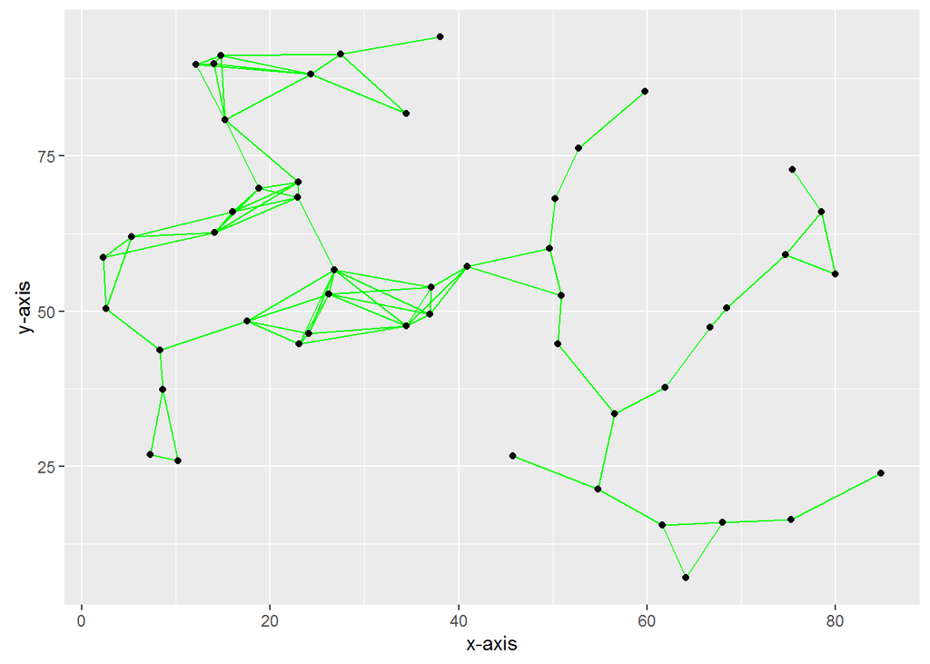

```r
# For the min
plotNetwork(nodes_min)
```

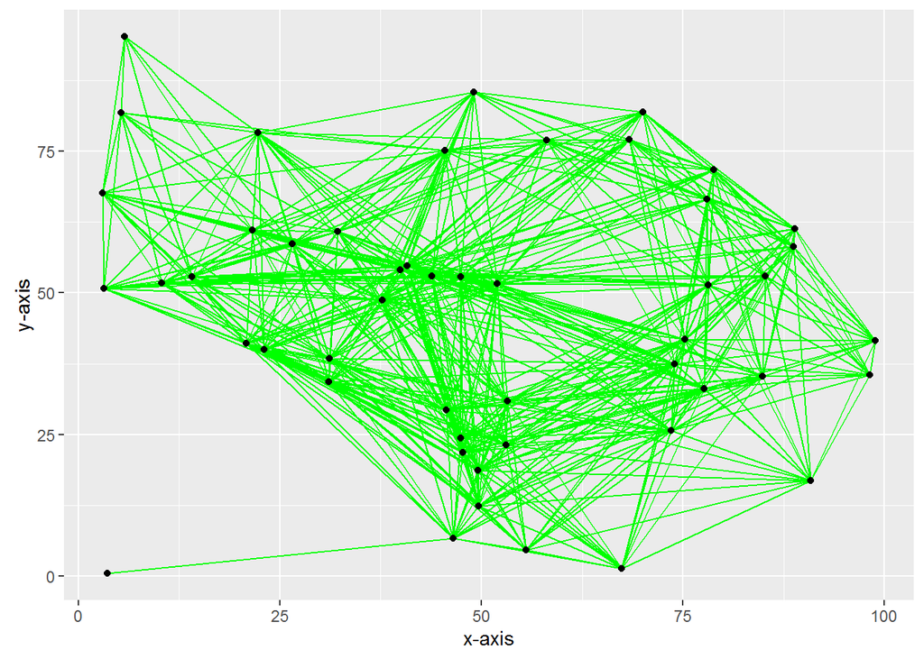

```r
# For the max
plotNetwork(nodes_max)
```

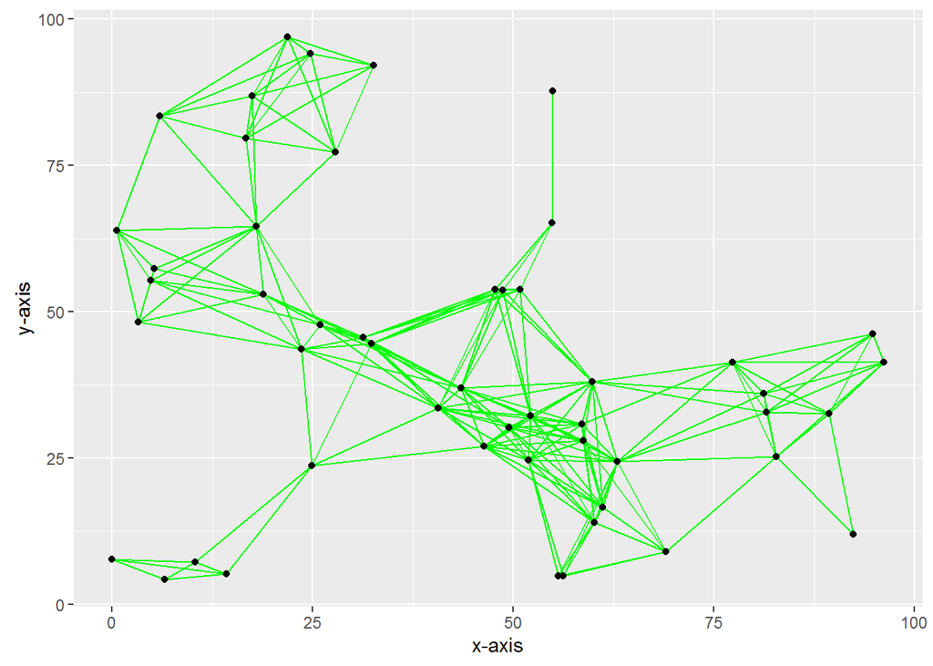

```r
# For the median
plotNetwork(nodes_median)
```

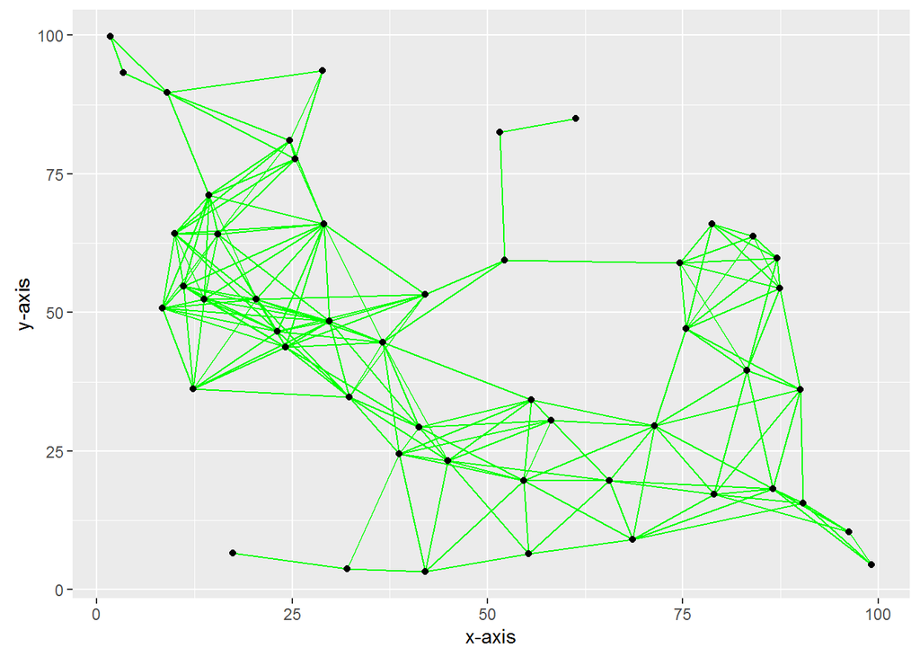

```r
# For the mean
plotNetwork(nodes_mean)
```

From the plots, we find that

1. For the connected network of the node configuration with the maximal Rc, the reason for Rc being large is the existence of an outlier near (0,0) with no close nodes nearby. Rc has to be large so that this outlier can be connected with others. As a result, there are more segments in this plot.
2. On the other hand, for the network of the connected points for the node configuration corresponding to the minimal Rc, every node happens to have at least one close neighbor. Hence, the network can be completely connected with a small Rc. Notice that every node having close neighbor(s) doesn’t necessarily imply all nodes cluster. Rather, the plot shows that the nodes are just as scattered as their counterparts in any other plots. Given that a small Rc works for the connectivity of this node configuration which is normally scattered, logically it follows that the network would have fewer segments. This, as a matter of fact, further indicates the unstability of the connected network. To elaborate, since nodes are dynamic and connected with few counterparts, when they start moving around, it is highly likely that Rc is not big enough for the whole network to be connected.

To wrap up, Rc is small only if every node has close neighbor(s). As long as one node is far from others, Rc has to increase so that this node can be a part of this connected network. In reality, if every person is close to others, broadcasting power can be weak for people to successfully get through with others. Conversely, if there exists one person who is distant from other people, broadcasting power has to increase to allow him/her to communicate with others.

The analysis of the two extreme situations above explains why it is possible for Rc to take small and large values compared with mean/median values.